# Lección Unidades de medida luz

```python
import numpy as np
import scipy.misc
import pylab as plt

% matplotlib inline
```

```python
from IPython.display import display
from IPython.display import HTML
import IPython.core.display as di # Example: di.display_html('<h3>%s:</h3>' % str, raw=True)

# This line will hide code by default when the notebook is exported as HTML
di.display_html('<script>jQuery(function() {if (jQuery("body.notebook_app").length == 0) { jQuery(".input_area").toggle(); jQuery(".prompt").toggle();}});</script>', raw=True)

# This line will add a button to toggle visibility of code blocks, for use with the HTML export version
di.display_html('''<button onclick="jQuery('.input_area').toggle(); jQuery('.prompt').toggle();">Pulse para codigo</button>''', raw=True)
```

## Unidades de medida de la luz: integración python-arduino

Por: Edgar Rueda, Oscar Arnache

Última revisión del texto: noviembre 2016, por Edgar Rueda

### Onda plana electromagnética (TEM)

(Libro Saleh, sección 5.4)

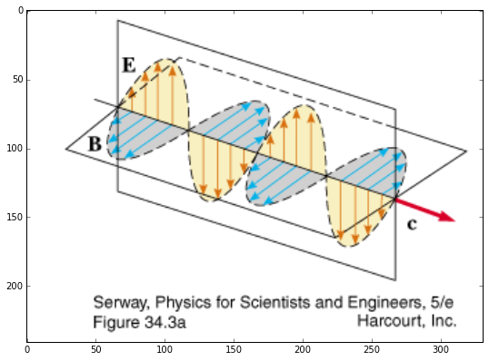

```python
Ima1 = scipy.misc.imread('TEM.png')

plt.figure(figsize=(9,9))
plt.imshow(Ima1)
```

Descripción de ondas monocromáticas

$$\pmb{E}(\pmb{r}) = \pmb{E_0} \exp(-i \pmb{k} \cdot \pmb{r})$$$$\pmb{H}(\pmb{r}) = \pmb{H_0} \exp(-i \pmb{k} \cdot \pmb{r})$$

donde la razón entre las amplitudes de los campos eléctrico y magnético es

$$\frac{E_0}{H_0} = \frac{\eta_0}{n} = \eta$$

$\eta$: impedancia del medio

$\eta_0$: impedancia del vacio. $\eta_0 \approx 120 \pi \Omega \approx 360 \Omega$

$n$: índice de refracción del medio

Dado que el flujo de potencia de un campo electromagnético está dado por el vector de Poynting $$\pmb{S} = \frac{1}{2} \pmb{E} \times \pmb{H}^*$$

La intensidad o irradiancia promedio (potencia por unidad de área) está dada por la expresión $$I = \frac{|\pmb{E_0}|^2}{2\eta}$$

El promedio es temporal en el periodo de oscilación de la onda armónica. Para una onda de amplitud máxima constante esto significa una intensidad constante.

Ejemplo:

Un láser pointer que emita luz láser de un milivatio de potencia (1 mW), y cuyo spot a la salida del láser tenga un diámetro de dos milímetros (2 mm) tendrá:

```python
P = 1.e-3 # [W]
d = 2.e-3 # [m]
eta = 360. # [Ohm]

I = P/(np.pi*d**2/4) # [W/m^2]
E0 = np.sqrt(I*2*eta) # [V/m]

print('Intensidad = %.f W/m^2' % I)
print('Amplitud de campo eléctrico = %.f V/m' % E0)
```

```
Intensidad = 318 W/m^2
Amplitud de campo eléctrico = 479 V/m
```

Nota: Es importante aclarar que dada la alta frecuencia de oscilación del campo electromagnético, en general la intensidad que se reporta (también conocidad como intensidad óptica) corresponde al promedio de la intensidad sobre un tiempo mucho más grande que el promedio de la onda. Esto depende del detector.

### Unidades de medida

(Libro Ryer A. Light measurement handbook, Internacional light, Capítulo 3)

Recordando la definición de ángulo sólido, la unidad de steradian corresponde al ángulo sólido que subtiende un área superficial de una esfera igual al cuadrado del radio formado por el cono centrado en el centro de la esfera. Una esfera tiene $4 \pi$ sterad.

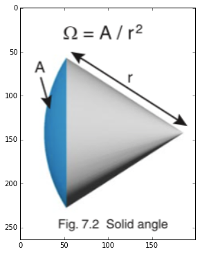

```python
Ima2 = scipy.misc.imread('angsolido.tiff')

plt.figure(figsize=(6,6))
plt.imshow(Ima2)
```

Nota: en sentido práctico el área superficial de la esfera se puede aproximar a un área plana cuando el detector se encuentre a una distancia de la fuente igual a 5 veces su mayor dimensión.

#### Unidades de potencia

El **flujo radiante** se entiende como la medida de la potencia radiométrica, donde se entiende por flujo como el flujo de energía por unidad de tiempo. **La unidad básica de medida es el vatio (W)**.

El **flujo luminoso** se entiende como la medida de la potencia fotométrica (de la luz visible), y está calibrada para la respuesta del ojo humano a la luz, el cual es más sensible al verde. **La unidad de medida es el lumen (lm)**.

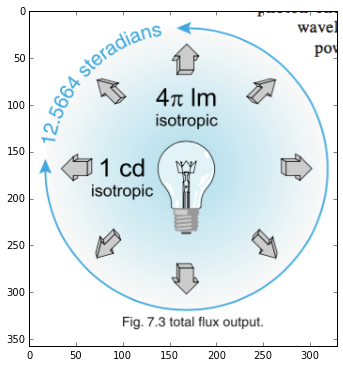

```python
Ima3 = scipy.misc.imread('flujo luminoso.tiff')

plt.figure(figsize=(6,6))
plt.imshow(Ima3)
```

#### Unidades de intensidad o irradiancia

La **irradiancia o intensidad** es una medida radiométrica de flujo (potencia) por unidad de área. **La unidad de medida básica es vatio por metro cuadrado (W/m^2)**.

La **iluminancia** es una medida fotométrica de flujo por unidad de área. **La unidad de medida es el lux (lm/m^2)**.

La **candela (cd)** es la unidad base de medida de la luz y se define como: una fuente de luz de 1 cd emite 1 lm/sterad en todas las direcciones (isotrópico).

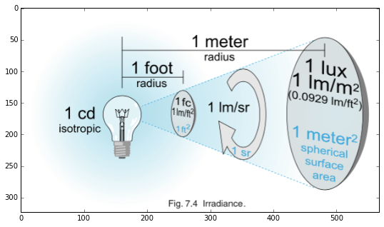

```python
Ima4 = scipy.misc.imread('luxes.tiff')

plt.figure(figsize=(9,9))
plt.imshow(Ima4)
```

#### Ley del coseno

Las medidas de irradiancia se deben hacer de forma tal que el detector esté perpendicular a la línea que une la fuente y el detector (eje óptico). La medida de irradiancia varía en función del coseno del ángulo entre el eje óptico y la normal al detector.

### Unidades de conversión

1 W = 683 lm a 555 nm

1 W/m^2 = 683 lux a 555 nm

Nota: existen otras unidades de medida como radiancia y luminancia. Para conocer sobre ellas referir al libro de Ryer.

## Integración Python-Arduino

Es bastante ventajoso poder controlar o procesar los datos arrojados por los sensores conectados al Arduino desde python. Para hacerlo existen dos formas, la primera se limita a leer la información que envía el arduino a través del puerto serial usando la librería serial-py; en la segunda se programa el Arduino para ser controlado a través de python usando la librería Firmata.

En esta ocasión obtendrémos la información de luxes de una fuente LED a través de una fotoresistencia de CdS. Para ello, desde python, controlaremos usando la librería firmata.py para generar una gráfica y guardar los datos de voltaje y brillo en un archivo txt.

```
Información típica de un fotoresistor y la relación entre resistencia Vs Iluminancia, se encuentra en los datasheets.
A continuación se presenta la arquitectura típica de un fotoresistor de CdS:
```

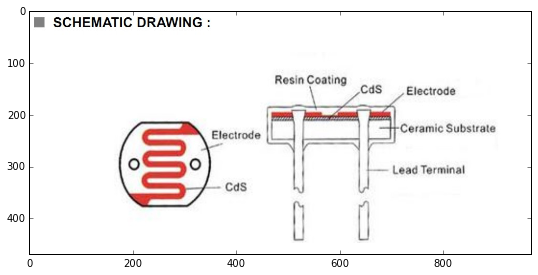

```python
Ima5 = scipy.misc.imread('CdS.jpg')

plt.figure(figsize=(9,9))
plt.imshow(Ima5)

print('Información típica de un fotoresistor y la relación entre resistencia Vs Iluminancia, se encuentra en los datasheets.')
print('A continuación se presenta la arquitectura típica de un fotoresistor de CdS:')
```

Instrucciones:

1. Contruir el circuito presentado en la siguiente figura.
2. Subir el programa StandardFirmata.ino a la tarjeta Arduino.
3. Abrir el programa de python LED-FR-rwg.py.
4. Modificar el programa para alcanzar los objetivos de la tarea.

Nota: en clase se harán ejemplos sencillos sobre el uso de Firmata.

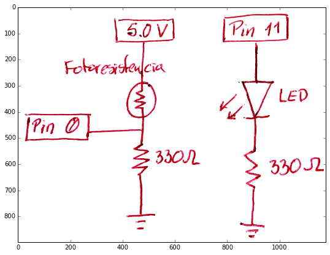

```python
Ima6 = scipy.misc.imread('LED-FR.png')

plt.figure(figsize=(9,9))
plt.imshow(Ima6)
```

Ejercicio:

1. Determinar el voltaje para brillo=0, con un número de datos superior a 30.
2. Determinar el voltaje para brillo=120, con un número de datos superior a 30.
3. Determinar el voltaje para brillo=120, restando el ruido. Usar propagación de errores.
4. Determinar la corriente a través del fotoresistor. Usar propagación de errores.
5. Determinar la resistencia en el fotoresistor. Usar propagación de errores.
6. Usar tabla de fabricante para convertir la resistencia a iluminancia.
7. Buscar en el libro de Ryer la equivalencia de luxes a W/m^2, para el LED usado.